# AMP-AD1.0 MSBB QC

Jessica Lundin and ADTR Science Team

September 16, 2026

# Definitions

**Abbreviations:** FP = frontal pole, IFG = inferior frontal gyrus, PG = parahippocampal gyrus, PC = prefrontal cortex, STG = superior temporal gyrus

To compare analysis results across studies (cross-cohort analysis) we chose to determine AD case/control status according to neuropathological data because cohorts had variable clinical and neuropathologic diagnostic information regarding AD case status.

**AD diagnosis:** Braak stage ≥ IV and CERAD measure equal to moderate/probable AD or frequent/definite AD.

**Control diagnosis:** Braak stage ≤ III and CERAD measure equal to none/no AD or sparse/possible AD.

Any donors who did not fall under diagnosis or control criteria were assigned as “other”.

**Starting dataset: n=1137 samples**

# Descriptive: Demographics

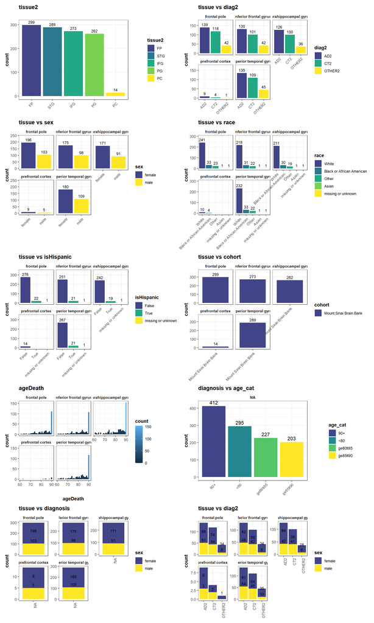

# Descriptive: Technical covariates

number of missing for PMI: 106

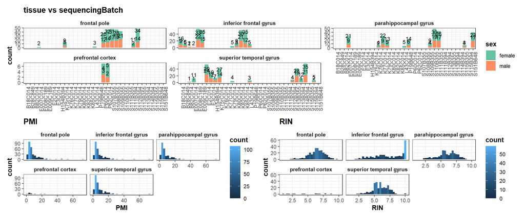

# RIN

**Samples were marked as QC failures if RIN was NA (n=0)**

RIN is a numerical value that indicates RNA integrity.

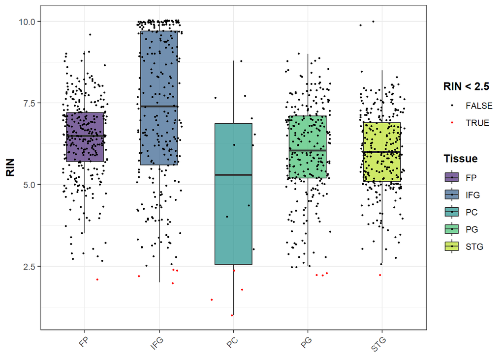

# Inferred sex

Examine average expression of key Y-chromosome genes to infer the sex of each sample. Genes used are RPS4Y1, EIF1AY, DDX3Y, and KDM5D, which were determined to be robust markers for sex in Staedtler, et al (2013).

Samples whose inferred sex did not match their reported sex were marked as QC failures (for now).

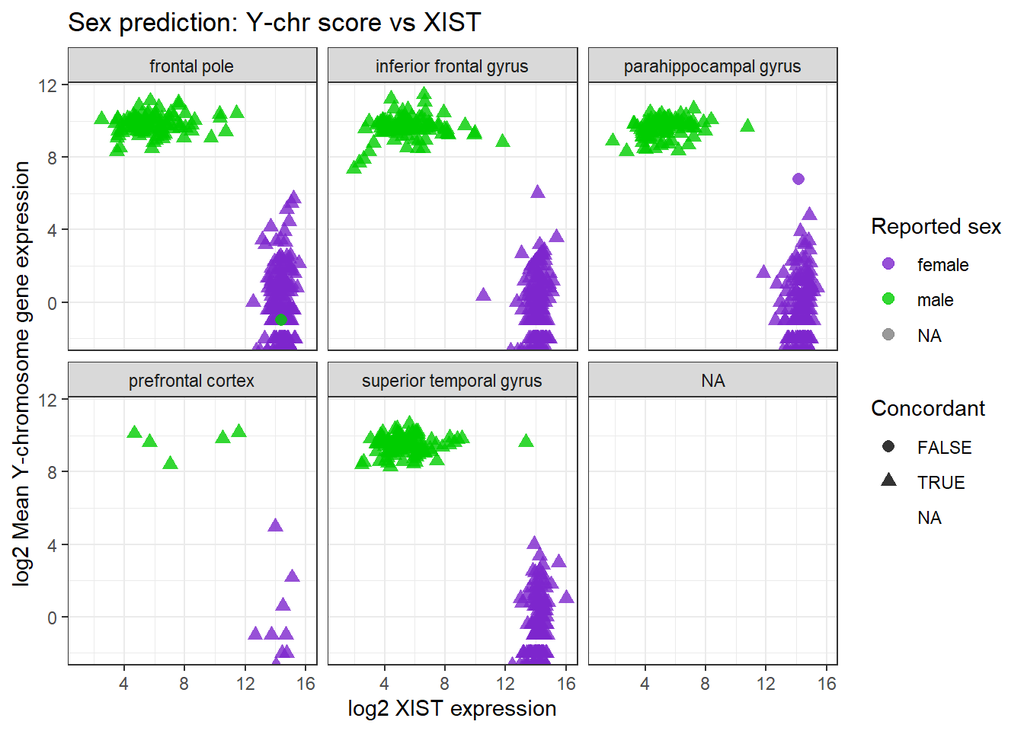

Reported sex vs inferred sex mismatches

| Specimen ID | Tissue | QC |
| --- | --- | --- |
| hB_RNA_12454 | FP | Discordant |
| BM_36_296 | PG | Discordant |

Reported sex vs inferred sex mismatches, with BM_36_296 (parahippocampal gyrus) marked as concordent due to being on the threshold

| Specimen ID | Tissue | QC |
| --- | --- | --- |
| hB_RNA_12454 | FP | Discordant |

# Validation for FastQC

Examine Phred score and average base content at each position of a read.

Samples fail QC if the Phred score is < 20.

Samples get a QC warning if the Phred score is below Q1 - 1.5 * IQR.

Samples get a QC warning if the base content is above Q3 + 1.5 * IQR for any base.

Samples with 2 or more warnings across all QC metrics fail QC.

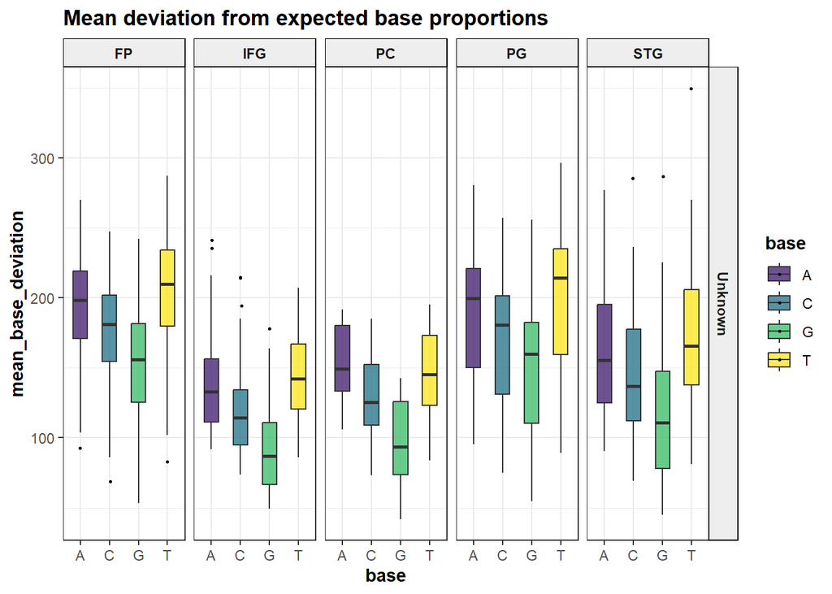

# Validation for MultiQC

Examined percentage of reads mapped and percentage of reads duplicated.

Samples were marked as QC failure if < 70% reads mapped or > 80% duplicated reads.

Samples were flagged as QC warning if reads mapped reported less than Q1 - 1.5 * IQR or duplicate reads reported more than Q3 + 3 * IQR. QC warnings were evaluated independently for each brain region (tissue type).

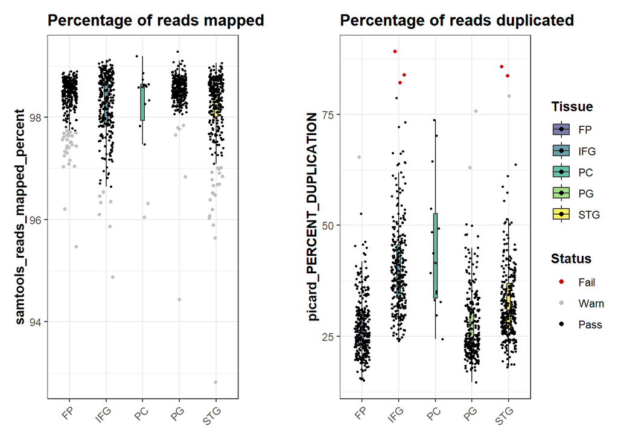

Samples not meeting MultiQC thresholds (failed QC)

| Specimen ID | Tissue | Reads Mapped | Reads Duplicated |
| --- | --- | --- | --- |
| hB_RNA_4782 | IFG | . | FAIL |
| hB_RNA_4923 | IFG | . | FAIL |
| hB_RNA_5011 | IFG | . | FAIL |
| BM_22_47 | STG | . | FAIL |
| BM_22_85 | STG | . | FAIL |

Samples flagged as MultiQC warning by Specimen IDs and Tissue Type

| Tissue | Count | SpecimenIDs |
| --- | --- | --- |
| FP | 28 | BM_10_554, BM_10_555, BM_10_561, BM_10_562, BM_10_566, BM_10_569, BM_10_571, BM_10_572, BM_10_588, BM_10_590, BM_10_597, BM_10_600, BM_10_602, BM_10_603, BM_10_605, BM_10_606, BM_10_607, BM_10_608, BM… |
| IFG | 10 | hB_RNA_4546, hB_RNA_4782, hB_RNA_4923, hB_RNA_5011, hB_RNA_8335, hB_RNA_8405, hB_RNA_8675, hB_RNA_8695, hB_RNA_8745, hB_RNA_8775 |
| PC | 2 | hB_RNA_12695, hB_RNA_13397 |
| PG | 8 | BM_36_302, hB_RNA_10922, hB_RNA_10992_L43C014, hB_RNA_11002_L43C014, hB_RNA_11012_L43C014, hB_RNA_11122, hB_RNA_12262_resequenced, hB_RNA_12302_E007C014 |
| STG | 22 | BM_22_105, BM_22_108, BM_22_47, BM_22_85, hB_RNA_10232_resequenced, hB_RNA_10242_resequenced, hB_RNA_7735, hB_RNA_7825, hB_RNA_7855, hB_RNA_8055_L43C014, hB_RNA_8075, hB_RNA_8095, hB_RNA_8255_L43C014,… |

# Final samples that passed QC

**1131 of 1137 samples passed QC.**

Samples by QC status

|  | FAIL | PASS | WARN |
| --- | --- | --- | --- |
| FP | 1 | 163 | 135 |
| IFG | 3 | 250 | 20 |
| PC | 0 | 0 | 14 |
| PG | 0 | 181 | 81 |
| STG | 2 | 218 | 69 |

Samples that failed QC by Tissue Type and Specimen ID

| Tissue | Count | Specimen ID |
| --- | --- | --- |
| FP | 1 | hB_RNA_12454 |
| IFG | 3 | hB_RNA_4782, hB_RNA_4923, hB_RNA_5011 |
| STG | 2 | BM_22_47, BM_22_85 |

Details of why each of 6 sample(s) failed QC. Added MultiQC and FastQC warning flags to existing QC failures, but these samples were not not excluded. Sample flagged as outliers for inferred sex were excluded, but shown separately from discordant failed samples.

| Specimen ID | Tissue | Sex fail | Sex outlier | RIN missing | MultiQC fail | MultiQC warn | FastQC Phred fail | FastQC phred warn | FastQC base content warn |
| --- | --- | --- | --- | --- | --- | --- | --- | --- | --- |
| hB_RNA_12454 | FP | FAIL | . | . | . | WARN | . | WARN | . |
| hB_RNA_4782 | IFG | . | . | . | FAIL | WARN | . | . | WARN |
| hB_RNA_4923 | IFG | . | . | . | FAIL | WARN | . | . | WARN |
| hB_RNA_5011 | IFG | . | . | . | FAIL | WARN | . | WARN | WARN |
| BM_22_47 | STG | . | . | . | FAIL | WARN | . | WARN | WARN |
| BM_22_85 | STG | . | . | . | FAIL | WARN | . | . | . |

# Metadata and clean counts

Uploaded to synapse: “MSBB_md_counts.rds”, parent = “syn76814282”

*1131 sample(s)*

*28242 genes(s)*

# CQN normalization

**Library preparation bias:** Library preparation method is a systematic technical covariate that affects GC content and gene length biases because these curves are not constant across library prep methods.

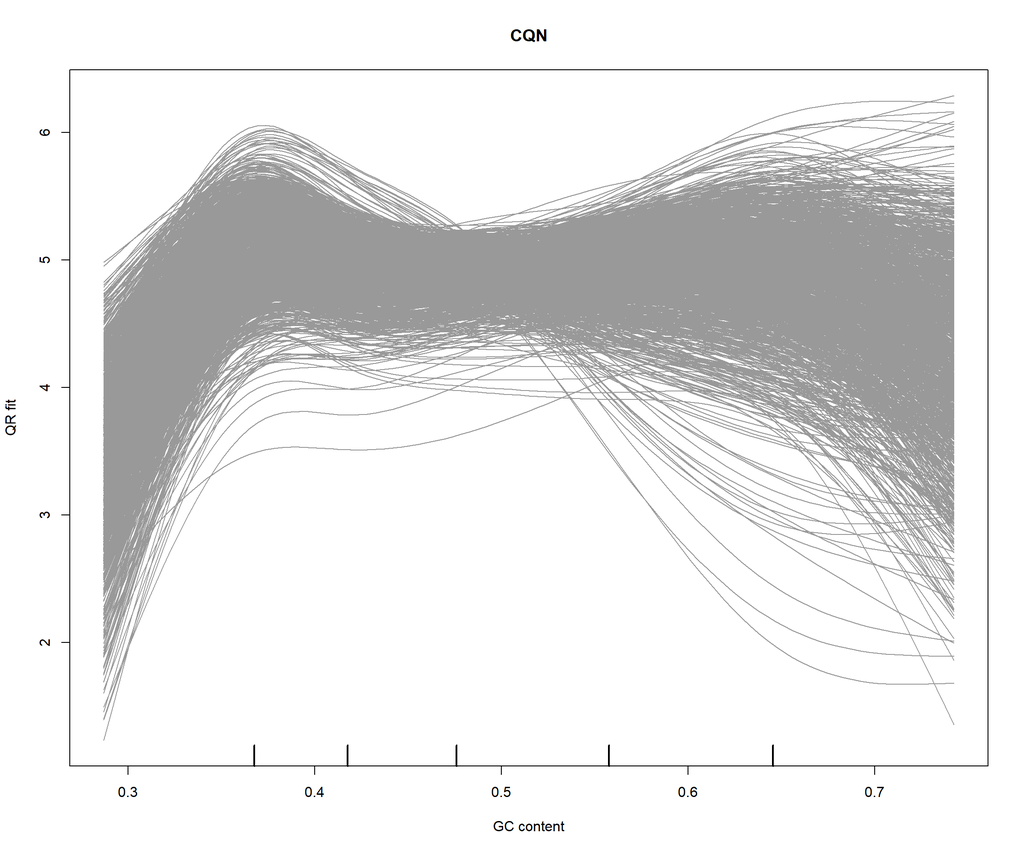

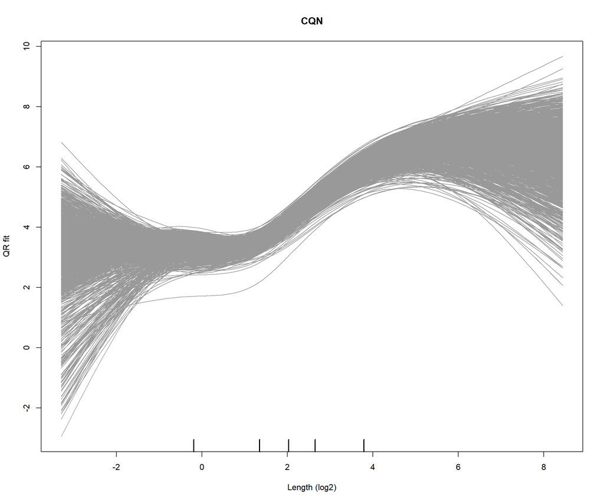

# Full data demographics (all tissues)

Sample Counts by Diagnosis and Sex across Tissues

| Diagnosis | female | male |
| --- | --- | --- |
| **FP** |  |  |
| AD2 | 88 | 50 |
| CT2 | 74 | 44 |
| OTHER2 | 34 | 8 |
| **PC** |  |  |
| AD2 | 6 | 3 |
| CT2 | 2 | 2 |
| OTHER2 | 1 | 0 |
| **IFG** |  |  |
| AD2 | 82 | 48 |
| CT2 | 57 | 41 |
| OTHER2 | 34 | 8 |
| **PG** |  |  |
| AD2 | 84 | 42 |
| CT2 | 59 | 41 |
| OTHER2 | 28 | 8 |
| **STG** |  |  |
| AD2 | 79 | 54 |
| CT2 | 64 | 45 |
| OTHER2 | 35 | 10 |

# RNA metrics PCs

Ran RAN metrics as principal components to account for technical variation, ran on FP, IFG, PG, and STG only since FC will not be in full model due to sample size

Variance explained by top PCs

| PC | variance |
| --- | --- |
| PC1 | 24.260 |
| PC2 | 21.547 |
| PC3 | 15.343 |
| PC4 | 7.819 |
| PC5 | 7.017 |
| PC6 | 5.760 |
| PC7 | 4.443 |
| PC8 | 3.497 |
| PC9 | 2.934 |
| PC10 | 2.257 |

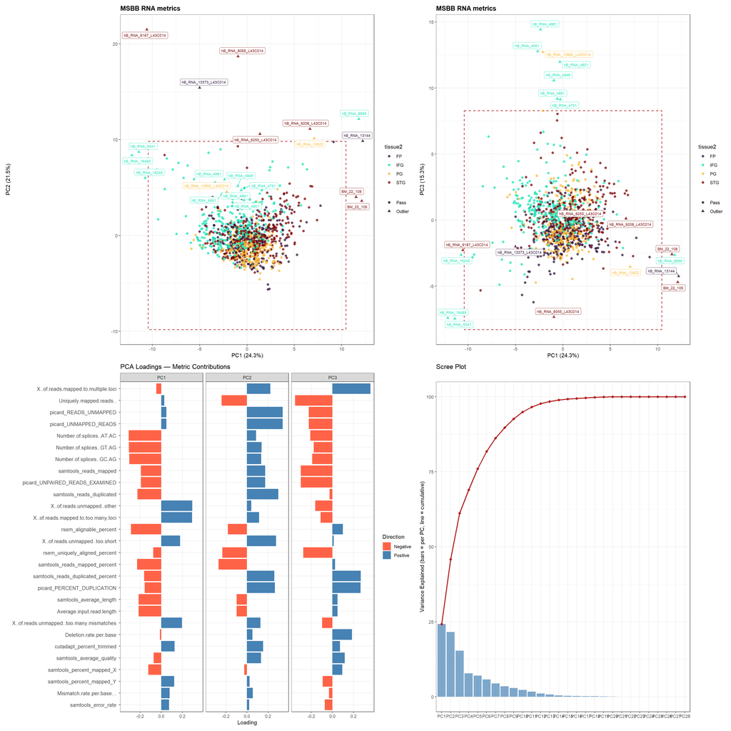

Additional samples dropped due to being outliers (>4 sd) in RNA metrics PCA analysis (n = 20)

| Specimen ID | Tissue | Sex | Diag2 |
| --- | --- | --- | --- |
| BM_22_105 | STG | male | AD2 |
| BM_22_108 | STG | female | OTHER2 |
| hB_RNA_10922 | PG | male | AD2 |
| hB_RNA_10992_L43C014 | PG | female | AD2 |
| hB_RNA_13144 | FP | female | AD2 |
| hB_RNA_13373_L43C014 | FP | female | CT2 |
| hB_RNA_16245 | IFG | female | OTHER2 |
| hB_RNA_16485 | IFG | male | AD2 |
| hB_RNA_4751 | IFG | female | OTHER2 |
| hB_RNA_4801 | IFG | male | CT2 |
| hB_RNA_4891 | IFG | male | AD2 |
| hB_RNA_4946 | IFG | female | CT2 |
| hB_RNA_4951 | IFG | male | CT2 |
| hB_RNA_4961 | IFG | male | CT2 |
| hB_RNA_5041 | IFG | male | CT2 |
| hB_RNA_8055_L43C014 | STG | female | AD2 |
| hB_RNA_8255_L43C014 | STG | female | AD2 |
| hB_RNA_8695 | IFG | male | AD2 |
| hB_RNA_9187_L43C014 | STG | male | CT2 |
| hB_RNA_9208_L43C014 | STG | male | AD2 |

# Final analytic dataset and models

**Demographics for FP, TFG, PG, and STG (for gene expression models)**

Final sample Counts by Diagnosis and Sex across Tissues

| Diagnosis | female | male |
| --- | --- | --- |
| **FP** |  |  |
| AD2 | 87 | 50 |
| CT2 | 73 | 44 |
| OTHER2 | 34 | 8 |
| **IFG** |  |  |
| AD2 | 82 | 45 |
| CT2 | 56 | 37 |
| OTHER2 | 32 | 8 |
| **PG** |  |  |
| AD2 | 83 | 41 |
| CT2 | 59 | 41 |
| OTHER2 | 28 | 8 |
| **STG** |  |  |
| AD2 | 77 | 52 |
| CT2 | 64 | 44 |
| OTHER2 | 34 | 10 |